# Brexit elasticities core results documentation

## Distribution graph

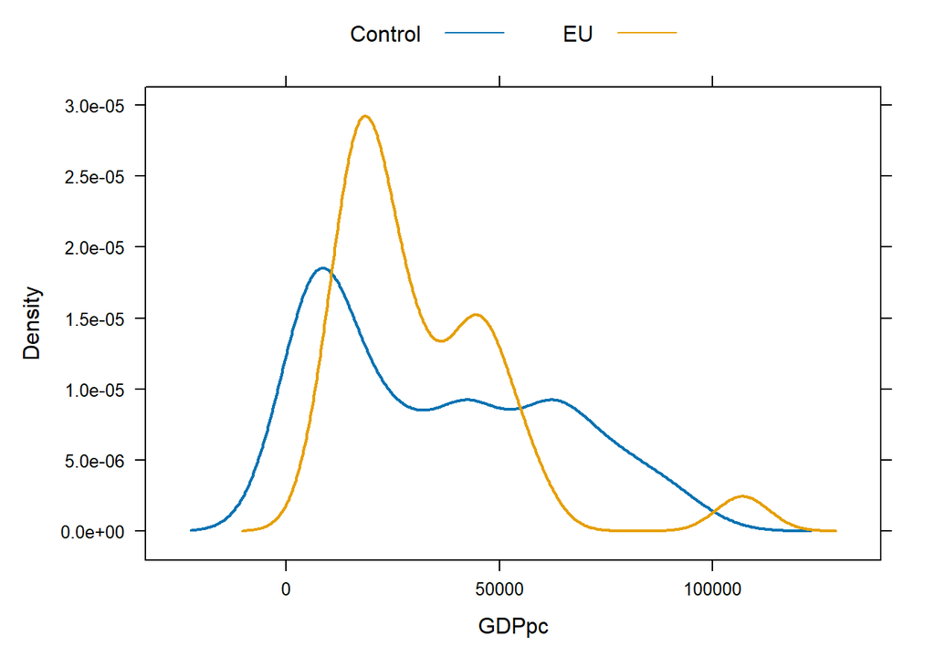

```r
library(dplyr)
library(lattice)

eu_countries <- data_panel %>% filter(Domicile_named_country %in% eu_real)
eu_control   <- data_panel %>% filter(Domicile_named_country %in% eu_synth)

eu_countries$group <- "EU"
eu_control$group   <- "Control"

df_plot <- rbind(eu_countries, eu_control) %>%
  mutate(Year = as.integer(as.character(Year)))

densityplot(~ GDPpc, group = group, data = df_plot,
            plot.points = FALSE, auto.key = list(columns = 2), lwd = 2)
```

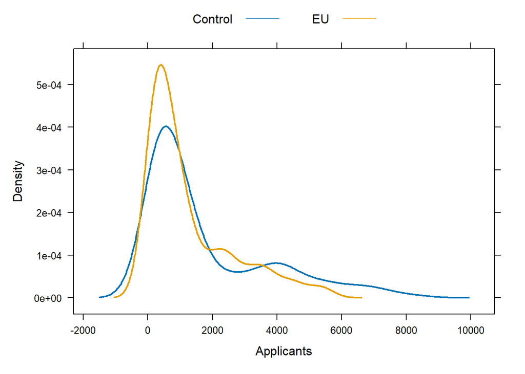

```r
densityplot(~ Applicants, group = group, data = df_plot,
            plot.points = FALSE, auto.key = list(columns = 2), lwd = 2)
```

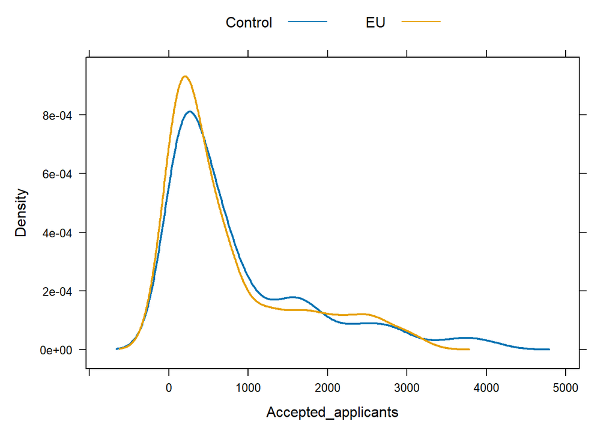

```r
densityplot(~ Accepted_applicants, group = group, data = df_plot,
            plot.points = FALSE, auto.key = list(columns = 2), lwd = 2)
```

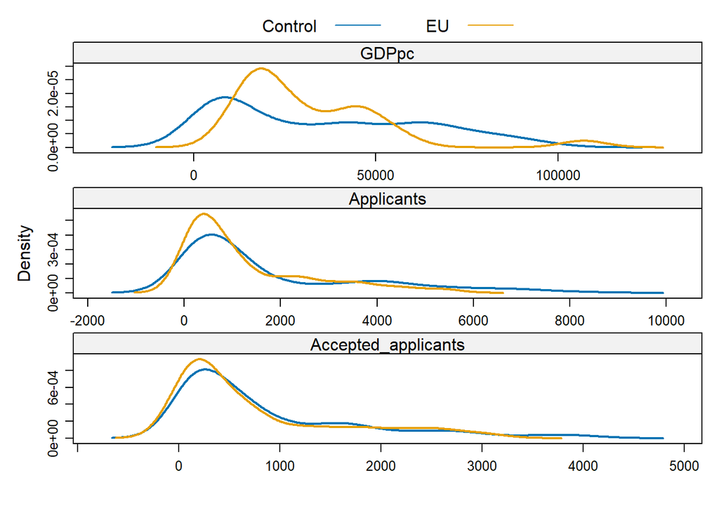

```r
densityplot(~ GDPpc + Applicants + Accepted_applicants,
            group = group, data = df_plot,
            plot.points = FALSE, auto.key = list(columns = 2), lwd = 2,
            layout = c(1, 3), as.table = TRUE,
            scales = list(relation = "free"),
            xlab = "")
```

## Descriptives (excel)

```r
library(dplyr)
library(openxlsx)

library(dplyr)
library(openxlsx)

desc_country <- df_plot %>%
  group_by(group, Domicile_named_country) %>%
  summarise(
    N = n(),

    GDP_mean = mean(GDPpc, na.rm = TRUE),
    GDP_sd   = sd(GDPpc, na.rm = TRUE),

    Applicants_mean = mean(Applicants, na.rm = TRUE),
    Applicants_sd   = sd(Applicants, na.rm = TRUE),

    Accepted_mean = mean(Accepted_applicants, na.rm = TRUE),
    Accepted_sd   = sd(Accepted_applicants, na.rm = TRUE),

    .groups = "drop"
  ) %>%
  arrange(group, Domicile_named_country)
desc_country_wide <- desc_country %>%
  tidyr::pivot_wider(
    names_from = group,
    values_from = c(
      GDP_mean, GDP_sd,
      Applicants_mean, Applicants_sd,
      Accepted_mean, Accepted_sd
    )
  )
write.xlsx(
  list(
    "Country-level (long)" = desc_country,
    "Country-level (wide)" = desc_country_wide
  ),
  file = "Country_Descriptives_Control_vs_Synthetic.xlsx",
  rowNames = FALSE
)
```

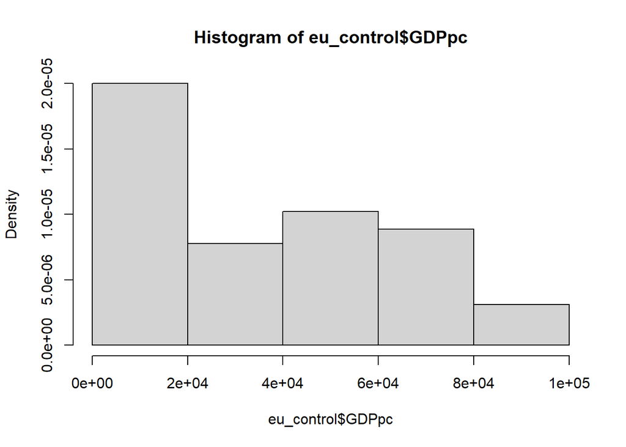

```r
h <- hist(
  eu_control$GDPpc,
  breaks = "FD",
  freq = FALSE,
  right = FALSE,
  plot = TRUE
)
```

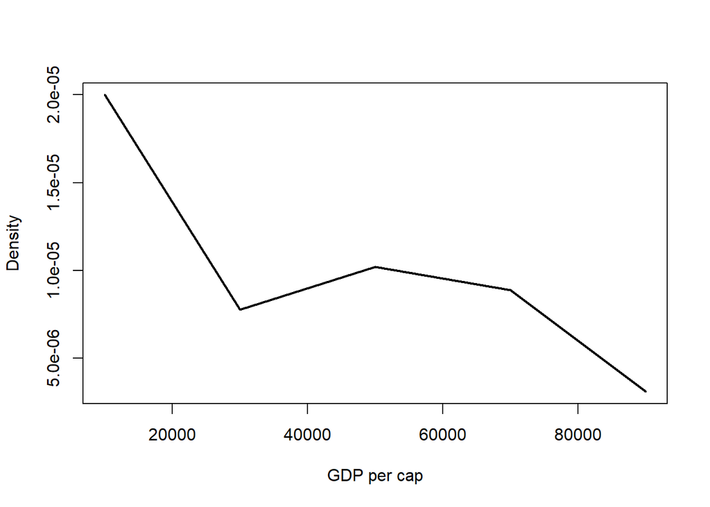

```r
plot(
  h$mids, h$density,
  type = "l",
  lwd = 2,
  xlab = "GDP per cap",
  ylab = "Density"
)
```

Note on how this was constructed: Assuming that there are K bin boundaries $b_0\leq b_1 \leq \dots\leq b_K$ separated into specific intervals $I_p=[b_p,b_{p+1}]$, the midpoint of those intervals is $m_p=\frac{b_p+b_{p+1}}{2}$ and the bins are defined as $\Delta_p=b_{p+1}-b_p$. $freq_p$ are the number of observations filling into bin $p$. The densities are given by:

$$density_p=\frac{freq_p}{obs \cdot \Delta_p }$$
where $obs$ denotes the number of observations in the sample. By construction the histogram integrates to unity $\left( E[x]=\int_{-\infty}^{+\infty} f(x)x dx=1 \right)$, hence the discrete version of this is given by:

$$\sum_{p=1}^K density_p\cdot \Delta_p$$
where $bin_p$ is $b_{j+1}-b_j$ (i.e. the sum of the probabilities of observing bin p somewhere in the distribution). To show the unity summation consider:

$$\sum_{1}^K density_p\cdot \Delta_p=\sum_{1}^K \frac{freq_p}{obs \cdot
\Delta_p }\cdot \Delta_p= \frac{\sum_{1}^K freq_p}{n}=n/n=1$$

```r
# Total observations
n <- sum(h$counts)

# Bin widths
binwidth <- diff(h$breaks)

# Manual density calculation
density_manual <- h$counts / (n * binwidth)

# Verification table
density_check <- data.frame(
  bin_left   = h$breaks[-length(h$breaks)],
  bin_right  = h$breaks[-1],
  midpoint   = h$mids,
  count      = h$counts,
  binwidth   = binwidth,
  density_R  = h$density,
  density_manual = density_manual,
  diff = h$density - density_manual
)

density_check
```

| bin_left | bin_right | midpoint | count | binwidth | density_R | density_manual | diff |
| --- | --- | --- | --- | --- | --- | --- | --- |
| 0 | 2e+04 | 10000 | 90 | 20000 | 2.000000e-05 | 2.000000e-05 | 0 |
| 20000 | 4e+04 | 30000 | 35 | 20000 | 7.777778e-06 | 7.777778e-06 | 0 |
| 40000 | 6e+04 | 50000 | 46 | 20000 | 1.022222e-05 | 1.022222e-05 | 0 |
| 60000 | 8e+04 | 70000 | 40 | 20000 | 8.888889e-06 | 8.888889e-06 | 0 |
| 80000 | 1e+05 | 90000 | 14 | 20000 | 3.111111e-06 | 3.111111e-06 | 0 |

```r
delta_2=20000-10000
density_2=18/(sum(h$counts)*delta_2)

density_2
```

```
## [1] 8e-06
```